# Network Analysis in Python (Part 1)

- William Surles
- 2018-01-09
- Datacamp class
- https://www.datacamp.com/courses/network-analysis-in-python-part-1

## Whats Covered

**Introduction to Networks**

- Introduction to networks
- Types of graphs
- Network visualization

**Important Nodes**

- Degree centrality
- Graph algorithms
- Betweenness centrality

**Structures**

- Cliques & communities
- Maximal cliques
- Subgraphs

**Bringing it all together**

- Case study!
- Case study part II: Visualization
- Case study part III: Cliques
- Case study part IV: Final tasks
- Final thoughts

## Additional Resources

- [NetworkX homepage](https://networkx.github.io/)
- [NetworkX documentation](https://networkx.github.io/documentation/networkx-1.10/reference/introduction.html)

## Libraries and Data

```python
import pickle
import numpy as np
import datetime
import warnings
warnings.filterwarnings("ignore")
```

# Introduction to Networks

## Introduction to networks

#### Networks!

- Examples:
  - Social
  - Transportation
- Model relationships between entities
- Insights:
  - Important entities: influencers in socual network
  - Pathfinding: most efficient transport path
  - Clustering: finding communities

#### Network structure

- Nodes are connected by edges
- Nodes can have metadata (like name and age)
- Edges can have metadata (like date friendship was mde)

#### NetworkX

- This is a python library that we will use in this class
- https://networkx.github.io/
- Its designed to analyse and manipulate complex networks
- you can create nodes and edges and add metadata

### Basics of NetworkX API, using Twitter network

```python
import networkx as nx
```

```python
Twitter = pickle.load( open( "data/ego-twitter.p", "rb" ) )
Twitter
```

```
<networkx.classes.digraph.DiGraph at 0x151be763c8>
```

```python
type(Twitter)
```

```
networkx.classes.digraph.DiGraph
```

```python
len(Twitter)
```

```
23369
```

```python
type(Twitter.nodes())
```

```
list
```

```python
Twitter.edges(data=True)[1]
```

```
(1, 4, {'date': datetime.date(2007, 6, 19)})
```

### Basic drawing of a network using NetworkX

#### Practice building a simple graph

- First, I practice making a simple graph
  - Otherwise the plots would be a mess
  - And the betweenness calcs later would take way too longs
  - I plot it at each stage

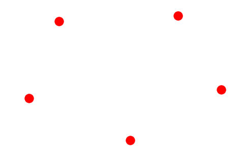

```python
T = nx.DiGraph()
T.add_nodes_from([1,2,3,4,5])

nx.draw(T)
plt.show()
```

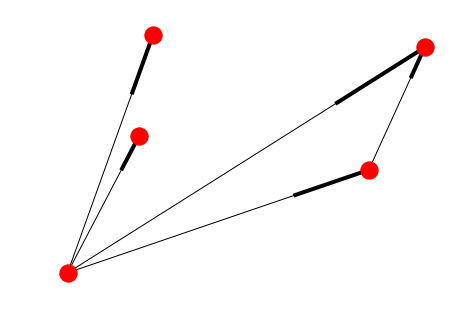

```python
T.add_edges_from([(1,2),(1,3),(1,4),(1,5),(2,3)])

nx.draw(T)
plt.show()
```

#### Build a graph with metadata

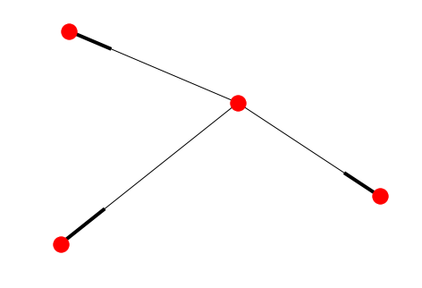

```python
import datetime
T = nx.DiGraph()
T.add_nodes_from([
 (1, {'category': 'I', 'occupation': 'scientist'}),
 (3, {'category': 'P', 'occupation': 'politician'}),
 (4, {'category': 'D', 'occupation': 'celebrity'}),
 (5, {'category': 'I', 'occupation': 'politician'})
])
T.add_edges_from([
 (1, 3, {'date': datetime.date(2012, 11, 17)}),
 (1, 4, {'date': datetime.date(2007, 6, 19)}),
 (1, 5, {'date': datetime.date(2014, 3, 18)}),
])

nx.draw(T)
plt.show()
```

#### Build the graph from the class

- Now I will create T based on the data in the class
  - This is all contained in T.py
  - I'll be using these same techniques but using the full list of nodes and edges from the graph in the class
  - I'll also include the node data

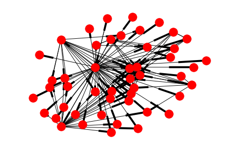

```python
%run data/T.py

nx.draw(T)
plt.show()
```

### Queries on a graph

```python
# Use a list comprehension to get the nodes of interest: noi
noi = [n for n, d in T.nodes(data=True) if d['occupation'] == 'scientist']
noi[:6]
```

```
[1, 7, 12, 18, 19, 23]
```

```python
T.edges(data=True)[-1]
```

```
(45, 41, {'date': datetime.date(2009, 5, 10)})
```

```python
# Use a list comprehension to get the edges of interest: eoi
eoi = [(u, v) for u, v, d in T.edges(data=True) if d['date'] < datetime.date(2010,1,1)]
eoi[:6]
```

```
[(1, 4), (1, 6), (1, 9), (1, 10), (1, 11), (1, 14)]
```

## Types of graphs

#### Undirected graphs

- One where the edges have no directionality
- Like a facebook graph
  - When two people become friends there is no direction. They are both just connected
  - This is commonly drawn as a line with no edges
- In networkx these have the type `graph`

```python
G = nx.Graph()
type(G)
```

```
networkx.classes.graph.Graph
```

#### Directed graphs

- One where the edges have a direction
- Like the twitter social graph
  - One user may follow another, but not vice versa
- This is drawn with an arrow between the nodes

```python
D = nx.DiGraph()
type(D)
```

```
networkx.classes.digraph.DiGraph
```

#### Multi Graphs

- One that can have multiple edges between nodes
- Like trips between bike sharing stataions
  - A bikes may travel one way between stations more often
- This is drawn as multiple arrows between nodes I guess.
- This can be directed like the bike sharing, or undirected like meetings between people

```python
M = nx.MultiGraph()
type(M)
```

```
networkx.classes.multigraph.MultiGraph
```

```python
MD = nx.MultiDiGraph()
type(MD)
```

```
networkx.classes.multidigraph.MultiDiGraph
```

- The multigraphs can get large in memory so its common to collapse the multiple edges into metadata with a value for the number of edges

#### Self-loops

- Nodes that are connected to themselves
  - Like in a bike sharing network, this would be a trip that starts and ends at the same station

### Specifying a weight on edges

- The next couple exercises are meant to work on the full Twitter network

```python
# Set the weight of the edge
Twitter.edge[1][10]['weight'] = 2
Twitter.edge[1][10]
```

```
{'date': datetime.date(2008, 10, 7), 'weight': 2}
```

```python
# Iterate over all the edges (with metadata)
for u, v, d in Twitter.edges(data=True):

    # Check if node 293 is involved
    if 293 in [u,v]:

        # Set the weight to 1.1
        d['weight'] = 1.1
        print(u,v,d)
```

```
232 293 {'date': datetime.date(2014, 7, 14), 'weight': 1.1}
```

### Checking whether there are self-loops in the graph

```python
Twitter.number_of_selfloops()
```

```
42
```

```python
# Define find_selfloop_nodes()
def find_selfloop_nodes(G):
    """
    Finds all nodes that have self-loops in the graph G.
    """
    nodes_in_selfloops = []

    # Iterate over all the edges of G
    for u, v in G.edges():

    # Check if node u and node v are the same
        if u == v:

            # Append node u to nodes_in_selfloops
            nodes_in_selfloops.append(u)

    return nodes_in_selfloops
```

```python
len(find_selfloop_nodes(Twitter))
```

```
42
```

```python
# Check whether number of self loops equals the number of nodes in self loops
assert T.number_of_selfloops() == len(find_selfloop_nodes(T))
```

- This is wierd because there should not be self loops in twitter data
  - I think these were just added in the example

## Network visualization

#### Other Network Visualizations

- The classic network visualization where you show all of the nodes and edes linking them has its drawbacks
  - It gets really messy and impossible to read or get value from with lots of data. Or even a medium amount of data
- 3 other types of plots that can give us more insight about a network:
- Matrix plot
  - This looks like a matrix heat map
  - It can show directed or undirected graphs
  - If undirected it will be symmetrical about the diagonal
  - A square is dark if there is a connection
  - If ordered it possible to see communities in the graph
- Arc plot
  - This has all the nodes in a line with arc representing connections
  - It works well for spatial graphs like transportation networks
- Circos plots
  - Like arc plot but the nodes form a circle. Arcs connect the nodes through the middle
  - Its very compact and visually efficient
  - First used in geneomics

#### nxviz API

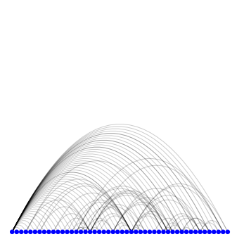

```python
import nxviz as nv
import matplotlib.pyplot as plt
ap = nv.ArcPlot(T)
ap.draw()
plt.show()
```

### Visualizing using Matrix plots

- nxviz is a package for visualizing graphs in a rational fashion.
  - Under the hood, the MatrixPlot utilizes nx.to_numpy_matrix(G), which returns the matrix form of the graph.
- Here, each node is one column and one row, and an edge between the two nodes is indicated by the value 1.
  - In doing so, however, only the weight metadata is preserved; all other metadata is lost.
- A corresponding nx.from_numpy_matrix(A) allows one to quickly create a graph from a NumPy matrix.
- The default graph type is Graph(); if you want to make it a DiGraph(), that has to be specified using the create_using keyword argument, e.g. (nx.from_numpy_matrix(A, create_using=nx.DiGraph)).

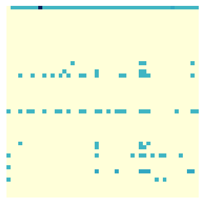

```python
# Import nxviz
import nxviz as nv

# Create the MatrixPlot object: m
m = nv.MatrixPlot(T)

# Draw m to the screen
m.draw()

# Display the plot
plt.show()

# Convert T to a matrix format: A
A = nx.to_numpy_matrix(T)

# Convert A back to the NetworkX form as a directed graph: T_conv
T_conv = nx.from_numpy_matrix(A, create_using=nx.DiGraph())

# Check that the `category` metadata field is lost from each node
for n, d in T_conv.nodes(data=True):
    assert 'category' not in d.keys()
```

### Visualizing using Circos plots

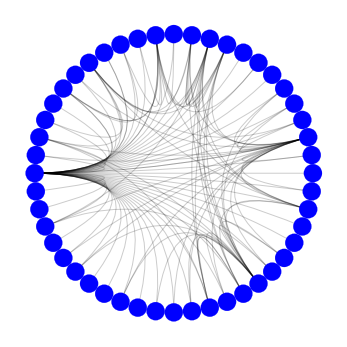

```python
# Import necessary modules
import matplotlib.pyplot as plt
from nxviz import CircosPlot

# Create the CircosPlot object: c
c = CircosPlot(T)

# Draw c to the screen
c.draw()

# Display the plot
plt.show()
```

### Visualizing using Arc plots

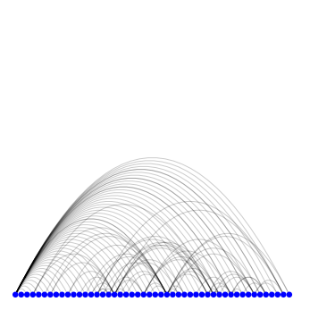

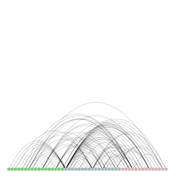

```python
# Import necessary modules
import matplotlib.pyplot as plt
from nxviz import ArcPlot

# Create the un-customized ArcPlot object: a
a = ArcPlot(T)

# Draw a to the screen
a.draw()

# Display the plot
plt.show()

# Create the customized ArcPlot object: a2
a2 = ArcPlot(T,
    node_order = 'category',
    node_color = 'category')

# Draw a2 to the screen
a2.draw()

# Display the plot
plt.show()
```

# Important nodes

## Degree centrality

- Which nodes are important?
  - Degree centrailty
  - Betweenness centrality

#### Degree centrality

- Definition:
  - [# of neighbors I have]/ [# of neighbors I could possibly have]
- Examples of nodes with high degree centrality:
  - Twitter broadcasters
  - Airport transportation hubs
  - Disease super-spreaders

### Compute number of neighbors for each node

```python
len(Twitter.neighbors(1))
```

```
47
```

```python
# Define nodes_with_m_nbrs()
def nodes_with_m_nbrs(G, m):
    """
    Returns all nodes in graph G that have m neighbors.
    """
    nodes = set()

    # Iterate over all nodes in G
    for n in G.nodes():

        # Check if the number of neighbors of n matches m
        if len(G.neighbors(n)) == m:

            # Add the node n to the set
            nodes.add(n)

    # Return the nodes with m neighbors
    return nodes

# Compute and print all nodes in T that have 6 neighbors
six_nbrs = nodes_with_m_nbrs(Twitter, 6)
print(six_nbrs)
```

```
{22533, 1803, 11276, 11279, 6161, 4261, 10149, 3880, 16681, 5420, 14898, 64, 14539, 6862, 20430, 9689, 475, 1374, 6112, 9186, 17762, 14956, 2927, 11764, 4725}
```

### Compute degree distribution

```python
# Compute the degree of every node: degrees
degrees = [len(T.neighbors(n)) for n in T.nodes()]

# Print the degrees
degrees[0:25]
```

```
[47, 0, 0, 0, 0, 0, 0, 0, 0, 0, 0, 0, 0, 0, 4, 0, 4, 15, 0, 0, 0, 0, 0, 0, 0]
```

### Degree centrality distribution

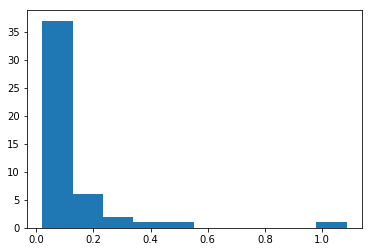

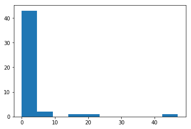

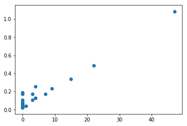

```python
# Import matplotlib.pyplot
import matplotlib.pyplot as plt

# Compute the degree centrality of the Twitter network: deg_cent
deg_cent = nx.degree_centrality(T)

# Plot a histogram of the degree centrality distribution of the graph.
plt.figure()
plt.hist(list(deg_cent.values()))
plt.show()

# Plot a histogram of the degree distribution of the graph
plt.figure()
plt.hist(degrees)
plt.show()

# Plot a scatter plot of the centrality distribution and the degree distribution
plt.figure()
plt.scatter(degrees, list(deg_cent.values()))
plt.show()
```

## Graph algorithms

#### Finding paths

- Pathfinding is important for
  - Optimization: e.g. shortest transport paths (like google maps)
  - Modeling: e.g. disease spread, information passing
- Algorithm: Breadth-first search

### Shortest Path

- This is an implementation of the bredth-first seach
- We write it over 3 exercises
- If the final node is in the list of neighbors, there is a path and you are done
  - otherwise you extend the queue with all nodes in the list of neighbors that have not been visited yet
  - keep going till you reach the last node in the queue, then return false

```python
def path_exists(G, node1, node2):
    """
    This function checks whether a path exists between two nodes (node1, node2) in graph G.
    """
    visited_nodes = set()
    queue = [node1]

    for node in queue:
        neighbors = G.neighbors(node)
        if node2 in neighbors:
            print('Path exists between nodes {0} and {1}'.format(node1, node2))
            return True
            break

        else:
            visited_nodes.add(node)
            queue.extend([n for n in neighbors if n not in visited_nodes])

        # Check to see if the final element of the queue has been reached
        if node == queue[-1]:
            print('Path does not exist between nodes {0} and {1}'.format(node1, node2))

            # Place the appropriate return statement
            return False
```

```python
path_exists(T, 1, 50)
```

```
Path does not exist between nodes 1 and 50
```

```
False
```

```python
path_exists(T, 1, 4)
```

```
Path exists between nodes 1 and 4
```

```
True
```

## Betweenness centrality

#### Betweenness centrality

- Set of paths
- Each path is shortest path between a given pair of nodes
- Node for all node pairs
- Definition
  - [# shortest paths throguh node]/[all possible shortest paths]
- Application:
  - Bridges between liberal and conservative learning Twitter users
  - Critical information transfer links on internet
  - Could be certain stations on a metro

#### Example

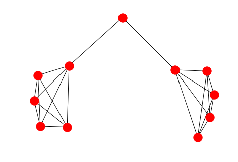

```python
import networkx as nx

G = nx.barbell_graph(m1=5, m2=1)
nx.draw(G)
plt.show()
```

```python
nx.betweenness_centrality(G)
```

```
{0: 0.0,
 1: 0.0,
 2: 0.0,
 3: 0.0,
 4: 0.5333333333333333,
 5: 0.5555555555555556,
 6: 0.5333333333333333,
 7: 0.0,
 8: 0.0,
 9: 0.0,
 10: 0.0}
```

### NetworkX betweenness centrality on a social network

- Betweenness centrality is a node importance metric that uses information about the shortest paths in a network.
- It is defined as the fraction of all possible shortest paths between any pair of nodes that pass through the node.

```python
# Compute the betweenness centrality of T: bet_cen
bet_cen = nx.betweenness_centrality(T)
```

```python
# Compute the degree centrality of T: deg_cen
deg_cen = nx.degree_centrality(T)
```

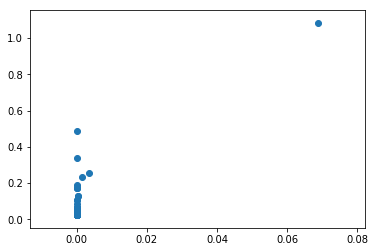

```python
# Create a scatter plot of betweenness centrality and degree centrality
plt.scatter(
    list(bet_cen.values()),
    list(deg_cen.values()))

# Display the plot
plt.show()
```

### Deep dive - Twitter network

```python
# Define find_nodes_with_highest_deg_cent()
def find_nodes_with_highest_deg_cent(G):

    # Compute the degree centrality of G: deg_cent
    deg_cent = nx.degree_centrality(G)

    # Compute the maximum degree centrality: max_dc
    max_dc = max(list(deg_cent.values()))

    nodes = set()

    # Iterate over the degree centrality dictionary
    for k, v in deg_cent.items():

        # Check if the current value has the maximum degree centrality
        if v == max_dc:

            # Add the current node to the set of nodes
            nodes.add(k)

    return nodes

# Find the node(s) that has the highest degree centrality in T: top_dc
top_dc = find_nodes_with_highest_deg_cent(T)
print(top_dc)

# Write the assertion statement
for node in top_dc:
    assert nx.degree_centrality(T)[node] == max(nx.degree_centrality(T).values())
```

```
{1}
```

### Deep dive - Twitter network part II

```python
# Define find_node_with_highest_bet_cent()
def find_node_with_highest_bet_cent(G):

    # Compute betweenness centrality: bet_cent
    bet_cent = nx.betweenness_centrality(G)

    # Compute maximum betweenness centrality: max_bc
    max_bc = max(list(bet_cent.values()))

    nodes = set()

    # Iterate over the betweenness centrality dictionary
    for k, v in bet_cent.items():

        # Check if the current value has the maximum betweenness centrality
        if v == max_bc:

            # Add the current node to the set of nodes
            nodes.add(k)

    return nodes

# Use that function to find the node(s) that has the highest betweenness centrality in the network: top_bc
top_bc = find_node_with_highest_bet_cent(T)
print(top_bc)

# Write an assertion statement that checks that the node(s) is/are correctly identified.
for node in top_bc:
    assert nx.betweenness_centrality(T)[node] == max(nx.betweenness_centrality(T).values())
```

```
{1}
```

# Structures

## Cliques & communities

- Social cliques: tightly-knit groups
- Network cliques: completely connected graphs
- Simplest complex clique: a triange
  - Friend recommendation systems (facebook, linkedin) will use this to try and recommend people I may know

#### Clique code

- The `combinations` function is usefule to search for cliques.
- It lets us iterate over all combinations of nodes.
- Here is a small example with a few nodes

```python
from itertools import combinations

for n1, n2 in combinations(T.nodes()[0:5], 2):
    print(n1,n2)
```

```
1 3
1 4
1 5
1 6
3 4
3 5
3 6
4 5
4 6
5 6
```

### Identifying triangle relationships

- This is a start to understanding and writing network algorithms

```python
from itertools import combinations

# Define is_in_triangle()
def is_in_triangle(G, n):
    """
    Checks whether a node `n` in graph `G` is in a triangle relationship or not.
    Returns a boolean.
    """
    in_triangle = False

    # Iterate over all possible triangle relationship combinations
    for n1, n2 in combinations(G.neighbors(n), 2):

        # Check if an edge exists between n1 and n2
        if G.has_edge(n1,n2):
            in_triangle = True
            break
    return in_triangle
```

```python
is_in_triangle(T, 1)
```

```
True
```

### Finding nodes involved in triangles

```python
from itertools import combinations

# Write a function that identifies all nodes in a triangle relationship with a given node.
def nodes_in_triangle(G, n):
    """
    Returns the nodes in a graph `G` that are involved in a triangle relationship with the node `n`.
    """
    triangle_nodes = set([n])

    # Iterate over all possible triangle relationship combinations
    for n1, n2 in combinations(T.neighbors(n), 2):

        # Check if n1 and n2 have an edge between them
        if G.has_edge(n1,n2):

            # Add n1 to triangle_nodes
            triangle_nodes.add(n1)

            # Add n2 to triangle_nodes
            triangle_nodes.add(n2)

    return triangle_nodes

# Write the assertion statement
assert len(nodes_in_triangle(Twitter, 1)) == 23
```

```python
len(nodes_in_triangle(T, 1))
```

```
23
```

### Finding open triangles

```python
from itertools import combinations

# Define node_in_open_triangle()
def node_in_open_triangle(G, n):
    """
    Checks whether pairs of neighbors of node `n` in graph `G` are in an 'open triangle' relationship with node `n`.
    """
    in_open_triangle = False

    # Iterate over all possible triangle relationship combinations
    for n1, n2 in combinations(G.neighbors(n), 2):

        # Check if n1 and n2 do NOT have an edge between them
        if not G.has_edge(n1,n2):

            in_open_triangle = True

            break

    return in_open_triangle

# Compute the number of open triangles in T
num_open_triangles = 0

# Iterate over all the nodes in T
for n in Twitter.nodes():

    # Check if the current node is in an open triangle
    if node_in_open_triangle(Twitter, n):

        # Increment num_open_triangles
        num_open_triangles += 1

print(num_open_triangles)
```

```
906
```

## Maximal cliques

- Definition: a clique that, when extended by one node is no longer a clique
- Application: community finding
- networkx api lets you find all maximal cliques with `find_cliques` command
  - note: this will include edges between two nodes

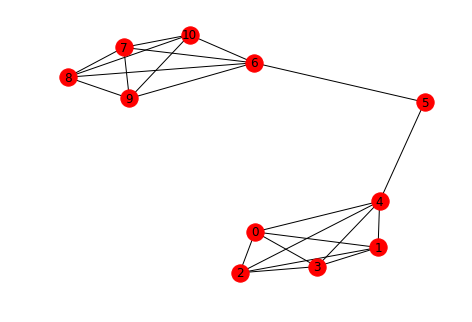

```python
import networkx as nx

G = nx.barbell_graph(m1 = 5, m2 = 1)
nx.draw(G, with_labels = True)
plt.show()
```

```python
list(nx.find_cliques(G))
```

```
[[4, 0, 1, 2, 3], [4, 5], [6, 5], [6, 7, 8, 9, 10]]
```

### Finding all maximal cliques of size "n"

```python
# Define maximal_cliques()
def maximal_cliques(G, size):
    """
    Finds all maximal cliques in graph `G` that are of size `size`.
    """
    mcs = []
    for clique in nx.find_cliques(G):
        if len(clique) == size:
            mcs.append(clique)
    return mcs
```

```python
list(nx.find_cliques(T.to_undirected()))
```

```
[[1, 3],
 [1, 4],
 [1, 6],
 [1, 9],
 [1, 10],
 [1, 12],
 [1, 13, 19],
 [1, 16, 48],
 [1, 16, 18, 35, 36],
 [1, 18, 36, 24],
 [1, 19, 36, 5],
 [1, 19, 36, 37, 24],
 [1, 19, 36, 37, 35],
 [1, 19, 8],
 [1, 19, 11],
```

[output cut: 44 more lines]

```python
len(maximal_cliques(T.to_undirected(), 3))
```

```
33
```

```python
# Check that there are 33 maximal cliques of size 3 in the graph T
assert len(maximal_cliques(T.to_undirected(), 3)) == 33
```

## Subgraphs

- Visualize portions of a large graph
  - Paths
  - Communities/cliques
  - Degrees of separation from a node

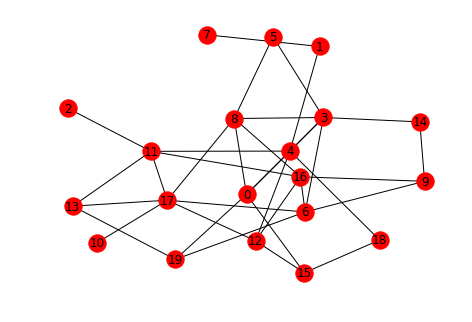

```python
G = nx.erdos_renyi_graph(n = 20, p = 0.2)

nx.draw(G, with_labels=True)
plt.show()
```

```python
nodes = G.neighbors(8)
nodes.append(8)
print(nodes)
G_eight = G.subgraph(nodes)
print(G_eight.edges())
```

```
[0, 3, 5, 16, 17, 8]
[(0, 3), (0, 8), (3, 5), (3, 8), (5, 8), (16, 8), (17, 8)]
```

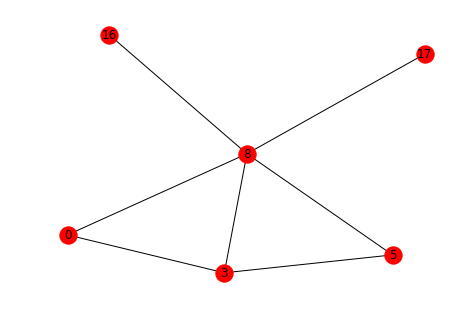

```python
nx.draw(G_eight, with_labels = True)
plt.show()
```

### Subgraphs I

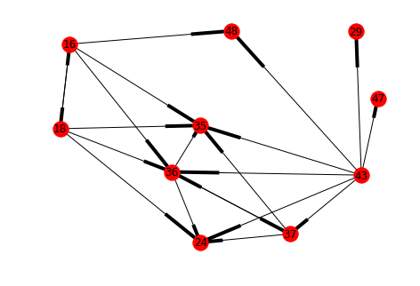

```python
nodes_of_interest = [18, 37, 43]

# Define get_nodes_and_nbrs()
def get_nodes_and_nbrs(G, nodes_of_interest):
    """
    Returns a subgraph of the graph `G` with only the `nodes_of_interest` and their neighbors.
    """
    nodes_to_draw = []

    # Iterate over the nodes of interest
    for n in nodes_of_interest:

        # Append the nodes of interest to nodes_to_draw
        nodes_to_draw.append(n)

        # Iterate over all the neighbors of node n
        for nbr in G.neighbors(n):

            # Append the neighbors of n to nodes_to_draw
            nodes_to_draw.append(nbr)

    return G.subgraph(nodes_to_draw)

# Extract the subgraph with the nodes of interest: T_draw
T_draw = get_nodes_and_nbrs(T, nodes_of_interest)

# Draw the subgraph to the screen
nx.draw(T_draw, with_labels = True)
plt.show()
```

### Subgraphs II

- Let's try one more exercise in which you extract nodes that have a particular metadata property and their neighbors.

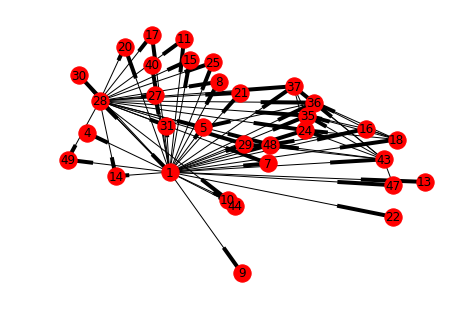

```python
# Extract the nodes of interest: nodes
nodes = [n for n, d in T.nodes(data=True) if d['occupation'] == 'celebrity']

# Create the set of nodes: nodeset
nodeset = set(nodes)

# Iterate over nodes
for n in nodes:

    # Compute the neighbors of n: nbrs
    nbrs = T.neighbors(n)

    # Compute the union of nodeset and nbrs: nodeset
    nodeset = nodeset.union(nbrs)

# Compute the subgraph using nodeset: T_sub
T_sub = T.subgraph(nodeset)

# Draw T_sub to the screen
nx.draw(T_sub, with_labels = True)
plt.show()
```

# Bringing it all together

## Case study!

#### Data

- Github user collaboration network
- Nodes: users
- Edges: collaboration on same GitHub repository
- Goals:
  - Analyze structure
  - Visualize
  - Build simple recommendation system

#### Graph properties

```python
G = nx.erdos_renyi_graph(n = 20, p = 0.2)
print(len(G.nodes()))
print(len(G.edges()))
```

```
20
38
```

```python
nx.degree_centrality(G)
```

```
{0: 0.05263157894736842,
 1: 0.3157894736842105,
 2: 0.2631578947368421,
 3: 0.21052631578947367,
 4: 0.21052631578947367,
 5: 0.15789473684210525,
 6: 0.15789473684210525,
 7: 0.15789473684210525,
 8: 0.15789473684210525,
 9: 0.15789473684210525,
 10: 0.05263157894736842,
 11: 0.21052631578947367,
 12: 0.21052631578947367,
 13: 0.2631578947368421,
 14: 0.3684210526315789,
 15: 0.21052631578947367,
 16: 0.21052631578947367,
 17: 0.2631578947368421,
 18: 0.21052631578947367,
 19: 0.15789473684210525}
```

```python
nx.betweenness_centrality(G)
```

```
{0: 0.0,
 1: 0.15999721526037317,
 2: 0.1480089111668059,
 3: 0.06390977443609021,
 4: 0.0720412141464773,
 5: 0.008771929824561401,
 6: 0.033973823447507656,
 7: 0.015594541910331385,
 8: 0.027290448343079917,
 9: 0.0043859649122807015,
 10: 0.0,
 11: 0.049902534113060414,
 12: 0.0686299081035923,
 13: 0.06318574213311054,
 14: 0.27832080200501247,
 15: 0.04841269841269841,
 16: 0.06223893065998329,
 17: 0.06638819270398218,
 18: 0.03654970760233918,
 19: 0.10818713450292397}
```

### Characterizing the network (I)

- I am going to create the small network they use in the class

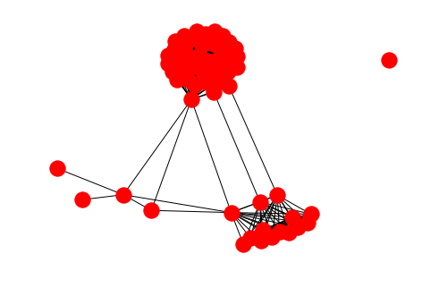

```python
# G = pickle.load( open( "data/github_users.p", "rb" ) )
%run data/G.py
nx.draw(G)
plt.show()
```

```python
print(len(G.nodes()))
print(len(G.edges()))
```

```
57
804
```

### Characterizing the network (II)

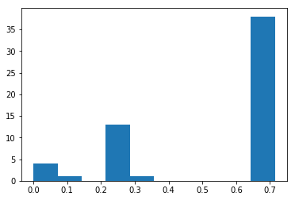

```python
# Import necessary modules
import matplotlib.pyplot as plt
import networkx as nx

# Plot the degree distribution of the GitHub collaboration network
plt.hist(list(nx.degree_centrality(G).values()))
plt.show()
```

### Characterizing the network (III)

- betweenness centraility is a very slow calculation in networkx
  - its O(nodes * edges). woof
- You can reduce the nodes it is calcualted on by using k
- I swithced to just use a small network from the class rather than the full dataset
- Here, I would have used k = 1000. this takes about 30 seconds which is as long as I want to wait
  - But the graph here does not look quite like what I say in the class
  - There were a couple humps with higher centrality

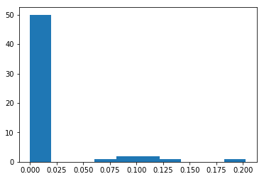

```python
# Import necessary modules
import matplotlib.pyplot as plt
import networkx as nx

# Plot the degree distribution of the GitHub collaboration network
plt.hist(list(nx.betweenness_centrality(G).values()))
plt.show()
```

## Case study part II: Visualization

#### nxviz API

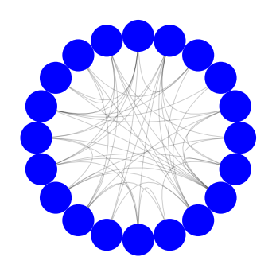

```python
G = nx.erdos_renyi_graph(n=20, p = 0.3)
circ = nv.CircosPlot(G)
circ.draw()
plt.show()
```

#### Connected component subgraphs

- Essentially, a graph with sections that do not connect

```python
G = nx.erdos_renyi_graph(n = 100, p = 0.03)
nx.connected_component_subgraphs(G)
```

```
<generator object connected_component_subgraphs at 0x157c290f10>
```

```python
list(nx.connected_component_subgraphs(G))
```

```
[<networkx.classes.graph.Graph at 0x157c20e588>,
 <networkx.classes.graph.Graph at 0x157c348f60>,
 <networkx.classes.graph.Graph at 0x157c348f98>,
 <networkx.classes.graph.Graph at 0x157c307da0>]
```

```python
for g in list(nx.connected_component_subgraphs(G)):
    print(len(g.nodes()))
```

```
97
1
1
1
```

### MatrixPlot

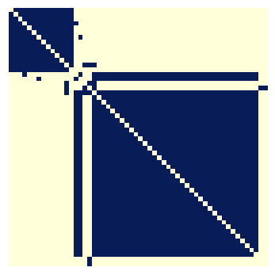

```python
# Import necessary modules
from nxviz import MatrixPlot
import matplotlib.pyplot as plt

# Calculate the largest connected component subgraph: largest_ccs
largest_ccs = sorted(
    nx.connected_component_subgraphs(G),
    key=lambda x: len(x)
    )[-1]

# Create the customized MatrixPlot object: h
# h = MatrixPlot(largest_ccs)
h = MatrixPlot(largest_ccs, node_grouping = 'grouping')

# Draw the MatrixPlot to the screen
h.draw()
plt.show()
```

### ArcPlot

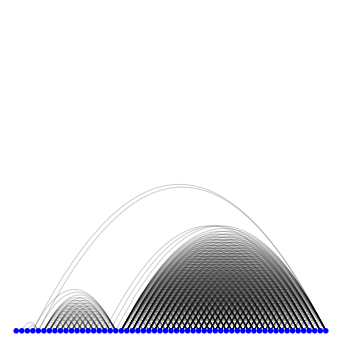

```python
# Import necessary modules
from nxviz.plots import ArcPlot
import matplotlib.pyplot as plt

# Iterate over all the nodes in G, including the metadata
for n, d in G.nodes(data=True):

    # Calculate the degree of each node: G.node[n]['degree']
    G.node[n]['degree'] = nx.degree(G, n)

# Create the ArcPlot object: a
a = ArcPlot(G, node_order = 'degree')

# Draw the ArcPlot to the screen
a.draw()
plt.show()
```

### CircosPlot

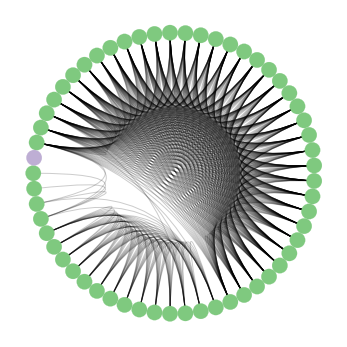

```python
# Import necessary modules
from nxviz import CircosPlot
import matplotlib.pyplot as plt

# Iterate over all the nodes, including the metadata
for n, d in G.nodes(data=True):

    # Calculate the degree of each node: G.node[n]['degree']
    G.node[n]['degree'] = nx.degree(G, n)

# Create the CircosPlot object: c
c = CircosPlot(G,
    node_order = 'degree',
    node_grouping = 'grouping',
    node_color = 'grouping')

# Draw the CircosPlot object to the screen
c.draw()
plt.show()
```

## Case study part III: Cliques

- See exercises above for a review on cliques if needed

### Finding cliques (I)

```python
# Calculate the maximal cliques in G: cliques
cliques = nx.find_cliques(G)

# Count and print the number of maximal cliques in G
print(len(list(cliques)))
```

```
8
```

### Finding cliques (II)

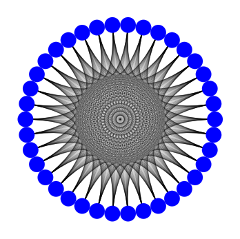

```python
# Import necessary modules
import networkx as nx
from nxviz import CircosPlot
import matplotlib.pyplot as plt

# Find the author(s) that are part of the largest maximal clique: largest_clique
largest_clique = sorted(nx.find_cliques(G), key=lambda x:len(x))[-1]

# Create the subgraph of the largest_clique: G_lc
G_lc = G.subgraph(largest_clique)

# Create the CircosPlot object: c
c = CircosPlot(G_lc)

# Draw the CircosPlot to the screen
c.draw()
plt.show()
```

- Ooooo, thats pretty

## Case study part IV: Final tasks

- Find important users
- Find the largest communities of collaborators
- Build a collaboration recommendation system

### Finding important collaborators

```python
# Compute the degree centralities of G: deg_cent
deg_cent = nx.degree_centrality(G)

# Compute the maximum degree centrality: max_dc
max_dc = max(deg_cent.values())

# Find the user(s) that have collaborated the most: prolific_collaborators
prolific_collaborators = [n for n, dc in deg_cent.items() if dc == max_dc]

# Print the most prolific collaborator(s)
print(prolific_collaborators)
```

```
['u2159']
```

### Characterizing editing communities

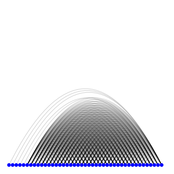

```python
# Import necessary modules
from nxviz import ArcPlot
import matplotlib.pyplot as plt

# Identify the largest maximal clique: largest_max_clique
largest_max_clique = set(sorted(nx.find_cliques(G), key=lambda x: len(x))[-1])

# Create a subgraph from the largest_max_clique: G_lmc
G_lmc = G.subgraph(largest_max_clique)

# Go out 1 degree of separation
for node in G_lmc.nodes():
    G_lmc.add_nodes_from(G.neighbors(node))
    G_lmc.add_edges_from(zip([node] * len(G.neighbors(node)), G.neighbors(node)))

# Record each node's degree centrality score
for n in G_lmc.nodes():
    G_lmc.node[n]['degree centrality'] = nx.degree_centrality(G_lmc)[n]

# Create the ArcPlot object: a
a = ArcPlot(G_lmc, node_order = 'degree centrality')

# Draw the ArcPlot to the screen
a.draw()
plt.show()
```

### Recommending co-editors who have yet to edit together

```python
# Import necessary modules
from itertools import combinations
from collections import defaultdict

# Initialize the defaultdict: recommended
recommended = defaultdict(int)

# Iterate over all the nodes in G
for n, d in G.nodes(data = True):

    # Iterate over all possible triangle relationship combinations
    for n1, n2 in combinations(G.neighbors(n), 2):

        # Check whether n1 and n2 do not have an edge
        if not G.has_edge(n1, n2):

            # Increment recommended
            recommended[(n1, n2)] += 1

# Identify the top 10 pairs of users
all_counts = sorted(recommended.values())

top10_pairs = [pair for pair, count in recommended.items() if count > all_counts[-10]]
print(top10_pairs)
```

```
[('u366', 'u3305'), ('u534', 'u2159'), ('u534', 'u322'), ('u366', 'u322')]
```